# Solutions to exercises of Week 2

*Disclaimer: this exercise is designed for you to practice with Python. The theory of mean-variance analysis is NOT part of the exam material. For this reason, most of derivations are skipped and the theory part is short.*

*Furthermore, this exercise is optional and should not be handed in. Unlike the assignment, the solution to these exercises will be shared and discussed, but it is strongly advised that you try on your own first.*

### Mean-variance optimization

We are interested in asset allocation, that is, how to construct an optimal portfolio of assets. We assume for simplicity that vector of $n$ stock returns is normally distributed with the mean vector $\mu$ and covariance matrix $\Sigma$, that is, $R \sim \mathcal{N}(\mu, \Sigma)$. Let us first read the data and obtain the vector of mean and covariance matrix, that will be needed for the analysis.

Import the relevant libraries:

```python
import pandas as pd
import pandas_datareader.data as web
import numpy as np
import matplotlib.pyplot as plt
import time
%matplotlib inline
```

We are interested in [components of the Euro STOXX 50](https://en.wikipedia.org/wiki/EURO_STOXX_50#Composition). For that fetch data from the web using `pandas_datareader`: read the list of tickers provided below from `yahoo`, we need only `'Adj Close'` prices from January 2019 to October 2021.

```python
tickers = ['ADS.DE','ADYEN.AS','AD.AS','AI.PA','AIR.PA','ALV.DE','AMS.MC','ABI.BR','ASML.AS','CS.PA',
           'BAS.DE','BAYN.DE','SAN.MC','BMW.DE','BNP.PA','CRG.IR','DAI.DE','BN.PA','DB1.DE','DPW.DE',
           'DTE.DE','ENEL.MI','ENGI.PA','ENI.MI','EL.PA','FLTR.IR','IBE.MC','ITX.MC','IFX.DE','INGA.AS',
           'ISP.MI','KER.PA','KNEBV.HE','OR.PA','LIN.DE','MC.PA','MUV2.DE','RI.PA','PHIA.AS','SAF.PA',
           'SAN.PA','SAP.DE','SU.PA','SIE.DE','TTE.PA','DG.PA','VIV.PA','VOW.DE','VNA.DE']
# UMG.AS and PRX.AS are excluded from the list since they have lots of missing data in yahoo

startdate = pd.datetime(2019, 1, 1)
enddate = pd.datetime(2021, 10, 30)  # Up to end of last month

df = pd.DataFrame() # Empty DataFrame
print("Finished downloading data for:")
for ticker in tickers:
    df[ticker] = web.DataReader(ticker, 'yahoo', start=startdate, end=enddate)['Adj Close']
    print(ticker)
    #time.sleep(1)

df.head()
```

[output not shown]

| Date | ADS.DE | ADYEN.AS | AD.AS | AI.PA | AIR.PA | ALV.DE | AMS.MC | ABI.BR | ASML.AS | CS.PA | ... | SAF.PA | SAN.PA | SAP.DE | SU.PA | SIE.DE | TTE.PA | DG.PA | VIV.PA | VOW.DE | VNA.DE |
| --- | --- | --- | --- | --- | --- | --- | --- | --- | --- | --- | --- | --- | --- | --- | --- | --- | --- | --- | --- | --- | --- |
| 2019-01-02 | 176.473129 | 470.899994 | 19.947470 | 90.383278 | 80.368752 | 150.678268 | 59.910358 | 52.264545 | 133.382614 | 14.645018 | ... | 101.552422 | 67.239326 | 82.001221 | 54.518482 | 88.764488 | 38.719509 | 65.734421 | 19.834459 | 125.426003 | 35.330864 |
| 2019-01-03 | 176.042480 | 463.049988 | 19.988068 | 88.722130 | 77.542427 | 149.094009 | 56.614510 | 52.901138 | 127.832283 | 14.523533 | ... | 99.245529 | 66.579422 | 79.456650 | 53.008682 | 86.384277 | 38.387547 | 65.513580 | 19.657032 | 124.873466 | 35.428291 |
| 2019-01-04 | 182.837280 | 500.000000 | 20.154974 | 91.192558 | 81.275848 | 152.710266 | 58.564713 | 55.056477 | 129.734146 | 14.979874 | ... | 103.270317 | 67.185822 | 81.464043 | 54.978786 | 89.769058 | 39.346092 | 66.783379 | 19.993208 | 129.754211 | 35.782574 |
| 2019-01-07 | 181.545319 | 531.200012 | 20.186546 | 90.681427 | 79.786301 | 151.470398 | 59.110767 | 54.820023 | 132.975067 | 14.912904 | ... | 101.552422 | 65.848167 | 81.633667 | 54.739426 | 88.592522 | 39.254799 | 66.452126 | 20.207989 | 130.951370 | 35.942001 |
| 2019-01-08 | 185.947571 | 569.900024 | 20.376007 | 90.809212 | 82.736748 | 151.625381 | 60.612431 | 55.902237 | 132.082352 | 14.968974 | ... | 104.497391 | 66.365387 | 82.905960 | 55.162907 | 88.945488 | 39.171818 | 67.298653 | 20.264019 | 132.240631 | 35.995144 |

5 rows × 49 columns

Check if the data for stocks is read well. Due to possible development issues on the yahoo's side, some of the stock data might be fetched with NaNs in every row. If this is the case, you can drop these stocks manually and proceed with remainings.

```python
df.isnull().sum()
#df = df.drop(columns=['ADS.DE'])
```

```
ADS.DE      0
ADYEN.AS    0
AD.AS       0
AI.PA       0
AIR.PA      0
ALV.DE      0
AMS.MC      0
ABI.BR      0
ASML.AS     0
CS.PA       0
BAS.DE      0
BAYN.DE     0
SAN.MC      0
BMW.DE      0
BNP.PA      0
CRG.IR      4
DAI.DE      0
BN.PA       0
DB1.DE      0
DPW.DE      0
DTE.DE      0
ENEL.MI     1
ENGI.PA     0
ENI.MI      1
EL.PA       0
FLTR.IR     4
IBE.MC      0
ITX.MC      0
IFX.DE      0
INGA.AS     0
ISP.MI      1
KER.PA      0
KNEBV.HE    9
OR.PA       0
LIN.DE      0
MC.PA       0
MUV2.DE     0
RI.PA       0
PHIA.AS     0
SAF.PA      0
SAN.PA      0
SAP.DE      0
SU.PA       0
SIE.DE      0
TTE.PA      0
DG.PA       0
VIV.PA      0
VOW.DE      0
VNA.DE      0
dtype: int64
```

Convert all the given closing prices into percentage log returns $r_t=100\log(P_t/P_{t-1})$ and drop all rows that contain at least one NaN:

```python
df_ret = 100*(np.log(df) - np.log(df.shift(1)))
df_ret = df_ret.dropna()
df_ret.tail()
```

| Date | ADS.DE | ADYEN.AS | AD.AS | AI.PA | AIR.PA | ALV.DE | AMS.MC | ABI.BR | ASML.AS | CS.PA | ... | SAF.PA | SAN.PA | SAP.DE | SU.PA | SIE.DE | TTE.PA | DG.PA | VIV.PA | VOW.DE | VNA.DE |
| --- | --- | --- | --- | --- | --- | --- | --- | --- | --- | --- | --- | --- | --- | --- | --- | --- | --- | --- | --- | --- | --- |
| 2021-10-25 | 0.036064 | 0.448935 | 1.045831 | -0.111891 | -1.560664 | -0.151044 | -0.506701 | 0.630396 | -0.712168 | -0.062661 | ... | -2.528992 | 0.492263 | 2.008066 | -0.849861 | -0.387676 | 0.273564 | -0.907487 | -1.718480 | 1.992940 | -0.966551 |
| 2021-10-26 | 0.933079 | 1.573961 | -0.105853 | 0.349236 | 1.706307 | 1.420875 | 3.283664 | 1.634857 | -0.834851 | 2.149733 | ... | 4.269104 | 0.140207 | 1.873407 | 1.580607 | 1.669199 | -0.410632 | 1.872306 | -1.342299 | 4.141379 | -0.224388 |
| 2021-10-27 | -0.286181 | -2.022895 | 0.035292 | 0.764056 | 0.054558 | -0.049692 | 0.245484 | 0.050664 | 2.167823 | -0.163737 | ... | -0.409872 | 0.140001 | -0.940321 | 2.379749 | -0.467989 | -0.251775 | 0.043636 | -0.451470 | -2.533512 | 0.708828 |
| 2021-10-28 | 1.740099 | -1.378030 | -0.886216 | -0.638624 | 1.801851 | -0.124332 | 0.174982 | 9.832608 | 0.516806 | 0.020486 | ... | 1.840110 | 0.256173 | 1.114662 | 1.775231 | -0.613106 | -0.782243 | -0.021820 | 0.225985 | -3.816713 | 0.482111 |
| 2021-10-29 | -0.264387 | -0.763217 | 0.160100 | 0.444692 | -1.257880 | 0.099476 | 1.112667 | -3.152361 | 0.300232 | 3.005769 | ... | 1.703499 | 0.510386 | -0.778959 | 0.000000 | 0.314153 | 0.173082 | 0.760713 | 0.540302 | 1.146138 | -3.004361 |

5 rows × 49 columns

Calculate the mean, standard deviation and covariance matrix of returns and save them to separate variables `mu`, `std` and `Sigma` respectively:

```python
mu = df_ret.mean()
Sigma = df_ret.cov()
std = df_ret.std()
```

Make a scatterplot with `std` on the x-axis and `mu` on the y-axis. Make sure to add labels and a header. You can use `plt.scatter()` for that:

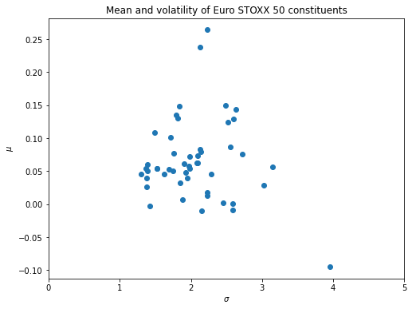

```python
plt.figure(figsize=(8,6))
plt.scatter(std, mu);
plt.xlim(0,5)
plt.xlabel(r'$\sigma$')
plt.ylabel(r'$\mu$')
plt.title('Mean and volatility of Euro STOXX 50 constituents');
```

The mean-variance portfolio choice problem is to choose portfolio weights $w = (w_1, \dots, w_n)'$ that minimize the portfolio variance given the expected return on that portfolio. In other words, a portfolio is called (mean-variance) efficient if its risk is no larger than any other feasible portfolio of the same expected return. Mathematically, the problem could be formulated as $$ \min_w \frac{1}{2} w' \Sigma w \\ \mbox{s.t. } w'\mu = \bar{\mu}_p \mbox{ and } w'e=1$$

where $e = (1,\dots,1)'$ is $n \times 1$ vector of ones and $\bar{\mu}_p = w' \mu$ is the expected portfolio return.

This is a quadratic optimization problem, which can be solved analytically in this case. The solution yields the following optimal portfolio weights:

$$ w_p = \lambda_1 \Sigma^{-1} \mu + \lambda_2 \Sigma^{-1} e $$

where $\lambda_1 = \frac{C \bar{\mu}_p - A}{D}$ and $\lambda_2 = \frac{B - A \bar{\mu}_p}{D}$ with $A = \mu' \Sigma^{-1} e, B = \mu' \Sigma^{-1} \mu, C = e' \Sigma^{-1} e$ and $D=BC - A^2$.

The minimized portfolio variance is then $$\sigma_p^2 = w_p' \Sigma w_p = \lambda_1 \bar{\mu}_p + \lambda_2 = \frac{1}{C} + \frac{C}{D} \left( \bar{\mu}_p - \frac{A}{C}\right)^2$$

A set of all pairs $(\sigma_p, \bar{\mu}_p)$, where $\sigma_p$ is the solution to optimization problem for a given expected return $\bar{\mu}_p$, is referred to as mean-variance efficient frontier.

Make a function `MV_RiskyPortfolio` that accepts the mean vector `mu`, covariance matrix `Sigma` and the expected level of portfolio return `mu_p` and returns the optimal portfolio weights and optimal portfolio variance.

*Hint:* use `@` (Python 3.x only) for matrix mulitplication and `np.linalg.inv` for matrix inversion.

```python
def MV_RiskyPortfolio(mu, Sigma, mu_p):
    '''Computes the weights and variance of the mean-variance efficient portfolio with expected return mu_p.'''

    e = np.ones(mu.shape)  # N x 1
    Sigma_inv = np.linalg.inv(Sigma)
    A = mu.T @ Sigma_inv @e
    B = mu.T @ Sigma_inv @mu
    C = e.T @ Sigma_inv @ e
    D = B*C - A**2

    wp = (mu_p*C - A)/D * Sigma_inv@mu + (B - A*mu_p)/D*Sigma_inv@e
    sigma2_p = wp.T @ Sigma @ wp

    return wp, sigma2_p
```

```python
mu_target = 0.1
wp, sigma2_p = MV_RiskyPortfolio(mu, Sigma, mu_target)
print(f'Optimal variance of mean-variance portfolio for a given expected returns of {mu_target}% is: {sigma2_p.round(2)}')
print(f'Optimal weights:\n{pd.Series(wp, index=mu.index)}')
```

```
Optimal variance of mean-variance portfolio for a given expected returns of 0.1% is: 0.67
Optimal weights:
ADS.DE     -0.022696
ADYEN.AS    0.093434
AD.AS       0.241583
AI.PA       0.077259
AIR.PA      0.014238
ALV.DE     -0.015137
AMS.MC      0.014080
ABI.BR     -0.065720
ASML.AS     0.082998
CS.PA       0.074208
BAS.DE      0.014887
BAYN.DE    -0.114403
SAN.MC     -0.011573
BMW.DE      0.107730
BNP.PA      0.069438
CRG.IR      0.005516
DAI.DE     -0.063421
BN.PA       0.091825
DB1.DE     -0.029669
DPW.DE      0.100994
DTE.DE      0.064004
ENEL.MI    -0.126881
ENGI.PA    -0.076493
ENI.MI     -0.127064
EL.PA       0.092256
FLTR.IR     0.029528
IBE.MC      0.133073
ITX.MC      0.003149
IFX.DE     -0.047918
INGA.AS     0.004982
ISP.MI      0.041486
KER.PA     -0.055145
KNEBV.HE    0.157852
OR.PA       0.011792
LIN.DE     -0.068087
MC.PA       0.045827
MUV2.DE    -0.017453
RI.PA       0.222687
PHIA.AS    -0.022301
SAF.PA     -0.037686
SAN.PA      0.138145
SAP.DE     -0.051632
SU.PA      -0.108844
SIE.DE     -0.000010
TTE.PA      0.126271
DG.PA      -0.122873
VIV.PA     -0.009900
VOW.DE      0.016245
VNA.DE      0.119415
dtype: float64
```

Plot a mean-variance efficient frontier and the previous scatter plot in $\sigma_p$, $\bar{\mu}_p$ space

```python
mu_y = np.linspace(-0.8, 0.8, 100)
sigma_x = [np.sqrt(MV_RiskyPortfolio(mu, Sigma, m)[1]) for m in mu_y]
# If a function has multiple output variables, you can immediately index into that:
# f(x)[i] will select the output of f(x) corresponding to index i.
```

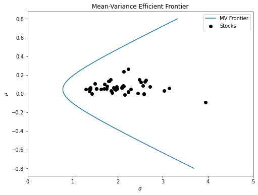

```python
# Figure
plt.figure(figsize=(8,6))
plt.plot(sigma_x, mu_y)
plt.xlim(0,5)
plt.scatter(std, mu, color='k')
plt.xlabel(r'$\sigma$')
plt.ylabel(r'$\mu$')
plt.legend(['MV Frontier','Stocks'])
plt.title('Mean-Variance Efficient Frontier');
```